# Data Science Lecture

Simon Anders

28 October 2019

## 3. Vorlesung (28.10.)

### Zunáchst ein Ratschlag

Der viele R-Code in diesem Dokument kann einschüchternd wirken. Ignorieren Sie allen Code also zunächst einfach. Sehen Sie sich nur den Text an und die Ergebnisse und Plots. Sie werden sehen, dass sich bereits so die Konzepte erschließen, und das ist das Wichtige. Zu lernen, die Details des R-Codes zu verstehen, und gar selbst in der Lage zu sein, solchen Code zu schreiben, ist zweitrangig.

Und keine Sorge: Ich werde von niemandem erwarten, derart komplexen Code selbständig in einer Klausur zu schreiben. Da wird es dann mehr um Verständnis eben dieser Konzepte gehen.

Und natürlich werden wir, wie versprochen, eben diese Konzepte in der nächsten Vorlesung nochmals durchsprechen, und ich werde auch einige Slides dazu vorbereiten.

### Null-Verteilung

In der zweiten Vorlesung hatten wir ein Beispiel für einen statisch stark signifikanten Unterschied zwiuschen zwei Gruppen: wir haben gefunden, dass im NAHNES-Datensatz Männer im Alter 60-80 Jahre im Mittel fast 3 cm kleiner sind als Männer im Alter 20-60 Jahre. Zum Vergleich schauen wir uns noch an, wie das aussieht, wenn wir eine Hypothese testen, die keinen Sinn macht, nämlich, dass Probanden, denen in der Umfrage eine geradzahlige Probanden-Nummer (“even”) zugewiesen wurde, einen andere Durchschnittsgröße haben als Probanden mit ungeradzahliger Nummer (“odd”).

Wir laden zunächste die Daten, wie zuvor

```r
suppressPackageStartupMessages( library( tidyverse ) )

haven::read_xpt( "~/w/Lecture/L1/DEMO_I.XPT" ) -> demo
haven::read_xpt( "~/w/Lecture/L1/BMX_I.XPT" ) -> bmx

inner_join( demo, bmx, by="SEQN" ) %>%
select(
  subjectId = SEQN,
  age = RIDAGEYR,
  sex = RIAGENDR,
  height = BMXHT,
  weight = BMXWT,
  ethnicity = RIDRETH3,
  education = DMDEDUC2,
  bornInUS = DMDBORN4,
  maritalStatus = DMDMARTL ) %>%
mutate(
  sex = fct_recode( factor(sex), "male"="1", "female"="2" ),
  ethnicity = fct_recode( factor(ethnicity),
       "mexican"="1", "hispanic"="2", "white"="3", "black"="4", "asian"="6", "other"="7" ),
  education = fct_recode( factor(education),
       "below9"="1", "9to11"="2", "high_school"="3", "some_college"="4",
       "college"="5", "dontknow"="9" ),
  bornInUS = fct_recode( factor(bornInUS),
       "yes"="1", "no"="2", "dontknow"="99" )
) ->  nhanes
```

Das folgende Dokument enthält einige Stellen, wo zufällige Daten ausgewürfelt werden. Der folgende Trick bewirkt, dass jedes Mal, wenn man es ausführt, dasselbe herauskommen wird:

```r
set.seed( 12345678 )
```

Wir filtern die Kinder aus und führen die neue Spalte mit der gerade/ungerade-Unterscheidung ein. Ausserdem, simulieren wir die Situation, dass wir nur sehr wenige Probanden haben, indem wir 20 zufällige Zeilen herausziehen und den Rest verwerfen.

```r
nhanes %>%
  filter( age > 20, !is.na(height) ) %>%
  sample_n( 20 ) %>%
  mutate( parity = ifelse( subjectId %% 2, "even", "odd" ) ) %>%
  select( subjectId, height, parity ) -> a
```

Unser Datentabelle sieht nun so aus

```r
a
```

```
## # A tibble: 20 x 3
##    subjectId height parity
##        <dbl>  <dbl> <chr>
##  1     88425   184. even
##  2     92559   171  even
##  3     84874   175  odd
##  4     84774   170. odd
##  5     86328   178. odd
##  6     86544   160. odd
##  7     91529   156  even
##  8     89370   173. odd
##  9     92829   158. even
## 10     93053   146. even
## 11     91324   164  odd
## 12     89756   181. odd
## 13     88065   155. even
## 14     88244   166. odd
## 15     87278   178. odd
## 16     85491   179. even
## 17     86553   184. even
## 18     83788   165. odd
## 19     91010   165. odd
## 20     92220   159. odd
```

Wie beim letzten mal berechnen wir den Mittelwert der Körpergröße der geraden und der ungeraden Personen:

```r
a %>%
  group_by( parity ) %>%
  summarise( mean_height = mean( height ) )
```

```
## # A tibble: 2 x 2
##   parity mean_height
##   <chr>        <dbl>
## 1 even          167.
## 2 odd           169.
```

Wir berechnen die Differenz:

```r
a %>%
  group_by( parity ) %>%
  summarise( mean_height = mean( height ) ) %>%
  spread( parity, mean_height ) %>%
  mutate( diff = even - odd ) %>%
  pull( diff ) -> parityDiff

parityDiff
```

```
## [1] -2.775
```

Wie beim letzten Mal wiederholen wir dies nun wieder 1000 mal, verwürfeln dabei aber jedes mal die Zuordnung von Probanden zu “odd” oder “even”:

```r
replicate( 1000, {
  a %>%
  mutate( parity = sample(parity) ) %>%
  group_by( parity ) %>%
  summarise( mean_height = mean( height ) ) %>%
  spread( parity, mean_height ) %>%
  mutate( diff = even - odd ) %>%
  pull( diff ) } ) -> nullDiffs
```

Hier ist ein Histogram der Nullverteilung, und mit einer grünen Linie, die “wahre” Differenz:

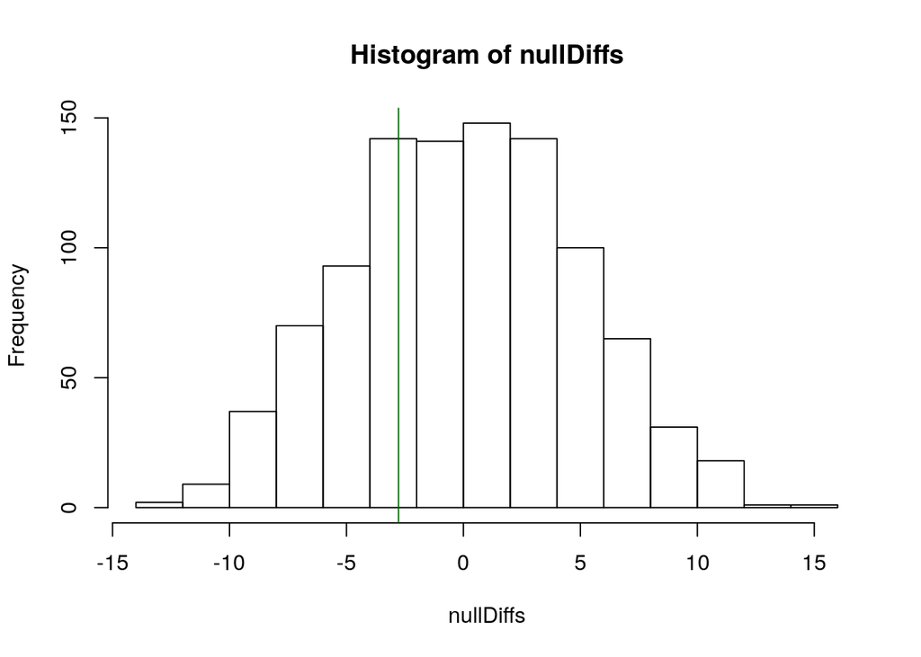

```r
hist(nullDiffs)
abline( v=parityDiff, col="darkgreen" )
```

Wir wir sehen gibt es sehr viele nullDiff-Werte, die weiter von der Mitte entfernt sind als der beobachtete Wert:

```r
table( nullDiffs < parityDiff )
```

```
##
## FALSE  TRUE
##   709   291
```

```r
table( nullDiffs > -parityDiff )
```

```
##
## FALSE  TRUE
##   691   309
```

```r
table( abs(nullDiffs) > abs(parityDiff) )
```

```
##
## FALSE  TRUE
##   400   600
```

Insgesamt sind 600 von 1000 Null-Werten extremer als der ohnen Permutation beobachtete Wert. Dieses Verhältnis, also `mean( abs(nullDiffs) > abs(parityDiff) )`, bezeichnet man als p-Wert.

Der p-Wert ist ein Maß für die statistche Signifikanz des Ergebnisses eines Hypothesentests. **Der p-Wert gibt an, wie wahrscheinlich es wäre, das beobachtete Ergebnis, oder ein noch stärkeres Ergebnis zu erhalten, wenn es den vermuteten Effekt nicht gäbe (wenn also die Null-Hypthese zuträfe).**

Bei unserem Test in der vorigen Vorlesung war keiner der 1000 Permutations-Werte extremer als die beobachteten 2.8 cm Unterschied zwischen alten und nicht-alten Männern. Der p-Wert für die Behauptung, dass die alten Männer kleiner sind, ist als kleiner als 1/1000 = 0.001. Das ist statistisch recht signifikant. Diesmal ist der p-Wert recht hoch, nämlich `mean( abs(nullDiffs) > abs(parityDiff) )`. Das ist nicht signifikant.

### RNA-Seq

Als ein erstes biologische Beispiel betrachten wir nun RNA-Seq-Daten von einer Studie zu Psoriasis (Schuppenflechte). Die Daten stammen von diesem Paper:

Li et al.: *Transcriptome Analysis of Psoriasis in a Large Case–Control Sample: RNA-Seq Provides Insights into Disease Mechanisms.* Journal of Investigative Dermatology, Volume 134, Pages 1828–1838 (July 2014). DOI: https://doi.org/10.1038/jid.2014.28

Die Autoren haben Hautproben von erkrankten Hautstellen von 92 Patienten mit Psoriasis genommen und von 82 Kontroll-Personen ohne Hautkrankheit, und für jede dieser Proben die Genexpression der Hautzellen mittels RNA-Seq gemessen.

Die präprozessierten Daten finden wir über das [ReCount2-Projekt](https://jhubiostatistics.shinyapps.io/recount/), dass aufbereitete Daten für viele RNA-Seq-Studien bereitstellt. Die Psoriasis-Studie findet sich hier unter Zugriffsnummer SRP035988; eine Daten-Matrix finden wir unter dieser URL: http://duffel.rail.bio/recount/v2/SRP035988/counts_gene.tsv.gz

```r
read_tsv( "counts_gene.tsv.gz" ) ->  countsWide
```

Die Matrix enthält eine Spalte für jeden Probanden, und eine Zeile für jedes Gen. hier, z.B. die ersten 5 Zeilen und letzten 5 Spalten

```r
countsWide[ 1:5, 175:179 ]
```

```
## # A tibble: 5 x 5
##   SRR1146250 SRR1146252 SRR1146253 SRR1146254 gene_id
##        <dbl>      <dbl>      <dbl>      <dbl> <chr>
## 1      42934      37011      32276      56866 ENSG00000000003.14
## 2       4574       3624       1026       3366 ENSG00000000005.5
## 3      59295      55653      69326     100762 ENSG00000000419.12
## 4      59140      36455      23744      51676 ENSG00000000457.13
## 5      23552      21826      16121      26538 ENSG00000000460.16
```

Die Spaltenüberschiften bezeichnen die Patienten. Die letzte Spalte enthält sog. Ensembl-Gene-IDs, die die verschiedenen Gene des menschlichen Genoms beschreiben.

Wir benötigen zunächst eine Tabelle, die diese IDs in verständliche Namen umsetzt. Diese Tabelle habe ich von Ensembl herunter geladen. (Wo man sie findet, zeige ich ein anderes Mal. Für jetzt finden Sie sie hier: gene_ids.tsv )

```r
read_tsv( "gene_ids.tsv" ) -> genes
head( genes )
```

```
## # A tibble: 6 x 3
##   gene_id       description                                          name
##   <chr>         <chr>                                                <chr>
## 1 ENSG00000210… mitochondrially encoded tRNA-Phe (UUU/C) [Source:HG… MT-TF
## 2 ENSG00000211… mitochondrially encoded 12S rRNA [Source:HGNC Symbo… MT-RN…
## 3 ENSG00000210… mitochondrially encoded tRNA-Val (GUN) [Source:HGNC… MT-TV
## 4 ENSG00000210… mitochondrially encoded 16S rRNA [Source:HGNC Symbo… MT-RN…
## 5 ENSG00000209… mitochondrially encoded tRNA-Leu (UUA/G) 1 [Source:… MT-TL1
## 6 ENSG00000198… mitochondrially encoded NADH:ubiquinone oxidoreduct… MT-ND1
```

(Klicken Sie auf die Pfeile, um alle drei Spalten zu sehen.)

Die Spaltenüberschiften in der großen Daten-Tabelle stehen für die Probanden. Auf ReCount2 finden wir auch eine Tabelle, die uns sagt, welche dieser Probanden gesund waren und welche krank: http://duffel.rail.bio/recount/SRP035988/SRP035988.tsv

```r
read_tsv( "SRP035988.tsv" ) -> head
```

Uns interessieren nur wenige dieser vielen Spalten:

```r
read_tsv( "SRP035988.tsv" ) %>%
select( sample = run, subject = title, condition = characteristics ) %>%
mutate( condition = fct_recode( condition,
  "normal" = "tissue type: normal skin",
  "psoriatic" = "tissue type: lesional psoriatic skin" ) ) -> sampleTable
sampleTable
```

```
## # A tibble: 179 x 3
##    sample     subject  condition
##    <chr>      <chr>    <fct>
##  1 SRR1146076 CASP1234 normal
##  2 SRR1146077 M3059    psoriatic
##  3 SRR1146078 M3171    psoriatic
##  4 SRR1146079 M3418    psoriatic
##  5 SRR1146080 M3978    psoriatic
##  6 SRR1146081 M4208    psoriatic
##  7 SRR1146082 M4257    psoriatic
##  8 SRR1146083 M4271    psoriatic
##  9 SRR1146084 M4271    psoriatic
## 10 SRR1146085 M4277    normal
## # … with 169 more rows
```

Um die große Datentabelle etwas handlicher zu machen, “pivotieren” wir sie, so dass jede Zeile nur noch eine Zahl enthält:

```r
countsWide %>%
  gather( sample, count, -gene_id ) -> countsLong

head(countsLong)
```

```
## # A tibble: 6 x 3
##   gene_id            sample     count
##   <chr>              <chr>      <dbl>
## 1 ENSG00000000003.14 SRR1146076 26160
## 2 ENSG00000000005.5  SRR1146076 10965
## 3 ENSG00000000419.12 SRR1146076 24011
## 4 ENSG00000000457.13 SRR1146076 22893
## 5 ENSG00000000460.16 SRR1146076  9436
## 6 ENSG00000000938.12 SRR1146076  7422
```

Die erste Zeile hier sagt uns nun z.B., dass in der Probe “SRR1146076” 26,160 RNA-Sequenzen gelesen wurden, die von Gen “ENSG00000000003.14” stammen.

Wir können unsere beiden anderen Tabellen nun hier anhängen. (Wenn Sie genau hingehen haben, werdem Sie bemerkt haben, dass die Gene-IDs in der counts-Tabelle etwas länger sidn als in der genes-Tabelle. Der merkwürdige mutate-Befehl im folgenden Code-Block entfernt diese Anhängsel.)

```r
countsLong %>%
mutate( gene_id = str_remove( gene_id, "\\.\\d+")) %>%
left_join( sampleTable ) %>%
left_join( genes ) %>%
head
```

```
## # A tibble: 6 x 7
##   gene_id   sample  count subject  condition description              name
##   <chr>     <chr>   <dbl> <chr>    <fct>     <chr>                    <chr>
## 1 ENSG0000… SRR114… 26160 CASP1234 normal    tetraspanin 6 [Source:H… TSPA…
## 2 ENSG0000… SRR114… 10965 CASP1234 normal    tenomodulin [Source:HGN… TNMD
## 3 ENSG0000… SRR114… 24011 CASP1234 normal    dolichyl-phosphate mann… DPM1
## 4 ENSG0000… SRR114… 22893 CASP1234 normal    SCY1 like pseudokinase … SCYL3
## 5 ENSG0000… SRR114…  9436 CASP1234 normal    chromosome 1 open readi… C1or…
## 6 ENSG0000… SRR114…  7422 CASP1234 normal    FGR proto-oncogene, Src… FGR
```

Nun sehen wir dass die erste Probe von einer gesunden Person kam, und das erste Gen das Symbol “TSPAN6” hat.

Zunächst möchten wir sehen, wie viele Sequenzen insgesamt von jeder Probe gelesen wurden:

```r
countsLong %>%
group_by( sample ) %>%
summarize( total = sum( count ) ) -> totals

head( totals )
```

```
## # A tibble: 6 x 2
##   sample          total
##   <chr>           <dbl>
## 1 SRR1146076 1709688143
## 2 SRR1146077  899080708
## 3 SRR1146078 1086360519
## 4 SRR1146079 3017300594
## 5 SRR1146080 2972110706
## 6 SRR1146081  848551151
```

Üblicherweise gibt man Genexpression in der Einheit “Trancripts per Million” (TPM) an, d.h., man gibt an, wieviele von jeweils einer Million Sequenzen von dem betreffenden Gen stammte. Daher müssen wir die Zähl-Werte durch die Gesamtzahl an Millionen Reads pro Probe teilen:

```r
countsLong %>%
left_join( totals ) %>%
mutate( tpm = count / ( total / 1000000 ) ) %>%
head
```

```
## # A tibble: 6 x 5
##   gene_id            sample     count      total   tpm
##   <chr>              <chr>      <dbl>      <dbl> <dbl>
## 1 ENSG00000000003.14 SRR1146076 26160 1709688143 15.3
## 2 ENSG00000000005.5  SRR1146076 10965 1709688143  6.41
## 3 ENSG00000000419.12 SRR1146076 24011 1709688143 14.0
## 4 ENSG00000000457.13 SRR1146076 22893 1709688143 13.4
## 5 ENSG00000000460.16 SRR1146076  9436 1709688143  5.52
## 6 ENSG00000000938.12 SRR1146076  7422 1709688143  4.34
```

Wir speichern dies als neue Tabelle

```r
countsLong %>%
mutate( gene_id = str_remove( gene_id, "\\.\\d+")) %>%
left_join( totals ) %>%
mutate( tpm = count / ( total / 1000000 ) ) %>%
select( gene_id, sample, tpm ) -> tpmTable
head( tpmTable )
```

```
## # A tibble: 6 x 3
##   gene_id         sample       tpm
##   <chr>           <chr>      <dbl>
## 1 ENSG00000000003 SRR1146076 15.3
## 2 ENSG00000000005 SRR1146076  6.41
## 3 ENSG00000000419 SRR1146076 14.0
## 4 ENSG00000000457 SRR1146076 13.4
## 5 ENSG00000000460 SRR1146076  5.52
## 6 ENSG00000000938 SRR1146076  4.34
```

Nun können wir für jedes Gen berchen, wie stark es exprimiert ist im Mittelwert über alle gesunden Proben und über all Läsions-Proben:

```r
tpmTable %>%
left_join( sampleTable ) %>%
group_by( gene_id, condition ) %>%
summarize( mean_tpm = mean( tpm ) ) -> a
head(a)
```

```
## # A tibble: 6 x 3
## # Groups:   gene_id [3]
##   gene_id         condition mean_tpm
##   <chr>           <fct>        <dbl>
## 1 ENSG00000000003 psoriatic    14.2
## 2 ENSG00000000003 normal       21.4
## 3 ENSG00000000005 psoriatic     1.12
## 4 ENSG00000000005 normal        3.01
## 5 ENSG00000000419 psoriatic    23.7
## 6 ENSG00000000419 normal       19.8
```

Die “spread”-Funktion erlaubt uns, die Werte für krank und gesund nebeneinder statt untereinander zu sehen:

```r
a %>% spread( condition, mean_tpm )
```

```
## # A tibble: 58,037 x 3
## # Groups:   gene_id [58,037]
##    gene_id         psoriatic normal
##    <chr>               <dbl>  <dbl>
##  1 ENSG00000000003     14.2   21.4
##  2 ENSG00000000005      1.12   3.01
##  3 ENSG00000000419     23.7   19.8
##  4 ENSG00000000457     15.0   17.1
##  5 ENSG00000000460      7.61   7.00
##  6 ENSG00000000938      6.66   5.04
##  7 ENSG00000000971    134.   226.
##  8 ENSG00000001036     28.8   39.1
##  9 ENSG00000001084     38.5   39.5
## 10 ENSG00000001167     19.2   19.3
## # … with 58,027 more rows
```

Wenn wir nun noch die Gen-Namen anhängen, haben wir eine schöne Tabelle mit unserem Ergebnis

```r
a %>%
spread( condition, mean_tpm ) %>%
left_join( genes ) -> resultTable
head( resultTable )
```

```
## # A tibble: 6 x 5
## # Groups:   gene_id [6]
##   gene_id     psoriatic normal description                           name
##   <chr>           <dbl>  <dbl> <chr>                                 <chr>
## 1 ENSG000000…     14.2   21.4  tetraspanin 6 [Source:HGNC Symbol;Ac… TSPAN6
## 2 ENSG000000…      1.12   3.01 tenomodulin [Source:HGNC Symbol;Acc:… TNMD
## 3 ENSG000000…     23.7   19.8  dolichyl-phosphate mannosyltransfera… DPM1
## 4 ENSG000000…     15.0   17.1  SCY1 like pseudokinase 3 [Source:HGN… SCYL3
## 5 ENSG000000…      7.61   7.00 chromosome 1 open reading frame 112 … C1orf…
## 6 ENSG000000…      6.66   5.04 FGR proto-oncogene, Src family tyros… FGR
```

Noch besser wird die Ergebnis-Tabelle, wenn wir auch noch die mittlere Expression jedes Gens, und des Verhältnis “krank geteilt durch gesund” einfügen:

```r
a %>%
spread( condition, mean_tpm ) %>%
mutate(
  mean_expr = ( normal + psoriatic )/2,
  ratio = psoriatic / normal ) %>%
left_join( genes ) -> resultTable
head( resultTable )
```

```
## # A tibble: 6 x 7
## # Groups:   gene_id [6]
##   gene_id   psoriatic normal mean_expr ratio description              name
##   <chr>         <dbl>  <dbl>     <dbl> <dbl> <chr>                    <chr>
## 1 ENSG0000…     14.2   21.4      17.8  0.662 tetraspanin 6 [Source:H… TSPA…
## 2 ENSG0000…      1.12   3.01      2.06 0.372 tenomodulin [Source:HGN… TNMD
## 3 ENSG0000…     23.7   19.8      21.8  1.20  dolichyl-phosphate mann… DPM1
## 4 ENSG0000…     15.0   17.1      16.1  0.875 SCY1 like pseudokinase … SCYL3
## 5 ENSG0000…      7.61   7.00      7.31 1.09  chromosome 1 open readi… C1or…
## 6 ENSG0000…      6.66   5.04      5.85 1.32  FGR proto-oncogene, Src… FGR
```

Nun können wir diese Tavbelle nach “ratio” sortieren und uns ein Gen aussuchen, das in den Läsions-Proben viel stärker exprimiert ist als in den Proben von gesunder Haut. Das Gen DYNAP (“dynactin associated protein”), mit ID “ENSG00000178690”, ist z.B. 21.9-fach hochreguliert. Das sehen wir uns mal genauer an:

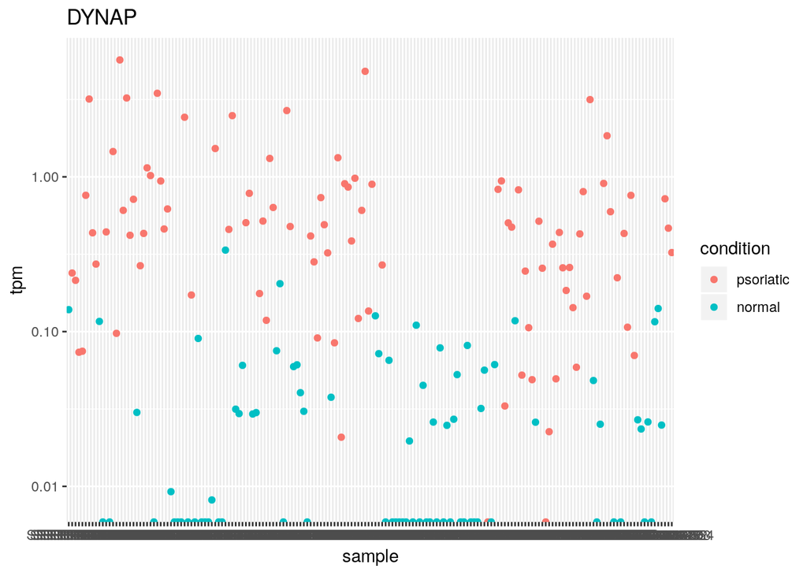

```r
tpmTable %>%
filter( gene_id == "ENSG00000178690" ) %>%
left_join( sampleTable ) %>%
ggplot +
   geom_point( aes( x=sample, y=tpm, col=condition) ) +
   scale_y_log10() +
   ggtitle( "DYNAP" )
```

Wir können uns auch einen Überblick verschaffen, indem wir jedes Gen in der “resultTable” durch einen Punkt darstellen:

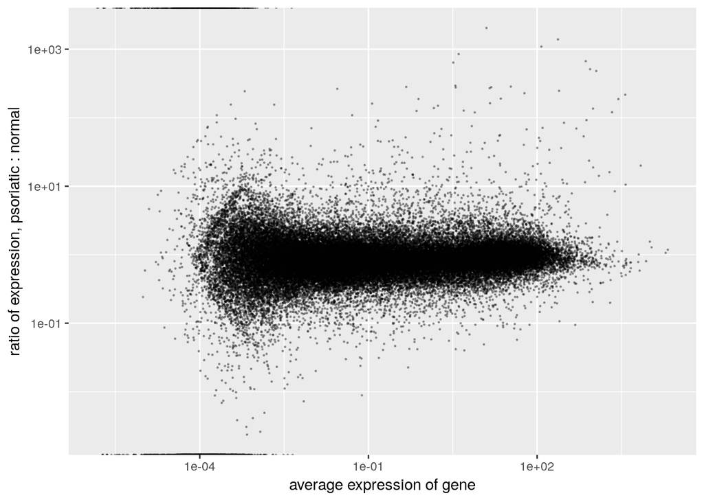

```r
resultTable %>%
ggplot +
  geom_point( aes( x=mean_expr, y=ratio ), size=.2, alpha=.3 ) +
  scale_x_log10() + scale_y_log10() +
  xlab( "average expression of gene" ) +
  ylab( "ratio of expression, psoriatic : normal" )
```

Jedes Gen ist hier ein Punkt; die Punkte weitb oben sind Gene, die in Psoriasis stark hochreguliert sind, die ganz unten stark “herunter-reguliert”. Man nennt diese Darstellung einen MA-Plot.

Als letztes wollen wir noch sehen, wie die Nullverteilung aussieht. Dazu wiederholen wir die Rechnung, die zur Results-Tabelle führte, permutieren aber vorher die Zuweisung von Proben zu “psoriatisch” oder “normal”:

```r
# randomly shuffle the condition column
sampleTable %>%
mutate( condition = sample( condition ) ) -> sampleTableShuffled

# Redo the calculation with the suffled table
tpmTable %>%
left_join( sampleTableShuffled ) %>%
group_by( gene_id, condition ) %>%
summarize( mean_tpm = mean( tpm ) ) %>%
spread( condition, mean_tpm ) %>%
mutate(
  mean_expr = ( normal + psoriatic )/2,
  ratio = psoriatic / normal ) %>%
left_join( genes ) -> resultTableShuffled
```

Ein neuer MA-Plot:

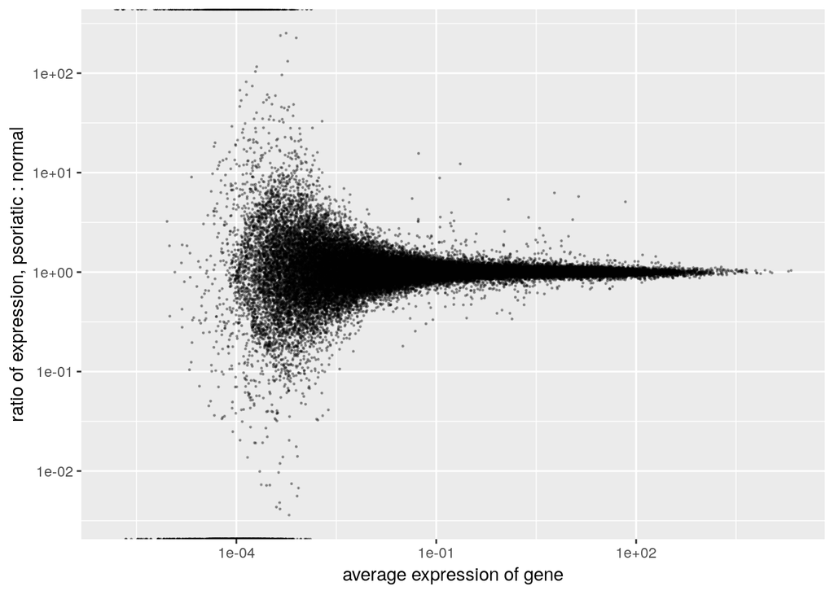

```r
resultTableShuffled %>%
ggplot +
  geom_point( aes( x=mean_expr, y=ratio ), size=.2, alpha=.3 ) +
  scale_x_log10() + scale_y_log10() +
  xlab( "average expression of gene" ) +
  ylab( "ratio of expression, psoriatic : normal" )
```

Beide Plots übereinander:

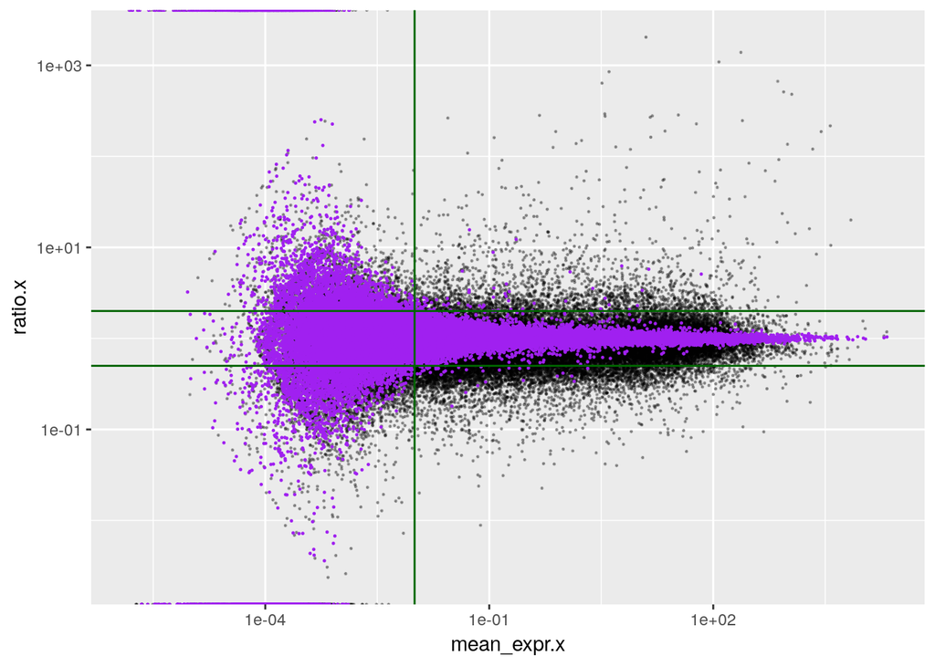

```r
left_join( resultTable, resultTableShuffled, by="gene_id" ) %>%
ggplot +
  geom_point( aes( x=mean_expr.x, y=ratio.x ), size=.2, alpha=.3 ) +
  geom_point( aes( x=mean_expr.y, y=ratio.y ), size=.2, col="purple" ) +
  scale_y_log10() +
  scale_x_log10() +
  geom_hline( yintercept = c( 2, 1/2 ), col="darkgreen" ) +
  geom_vline( xintercept = 0.01, col="darkgreen" )
```

Die grünen Linien markieren die Gene mit mean expression über 0.01 TPM und einem mindestens 2-fachen Verhältnis zwischen krank und gesund. Diese Bereiche enthalten wenige violette Punkte; daher möchten wir diese nun zunächst als unsere “signifikant differentiell exprimierten Gene” betrachten.

Wie viele sind das?

```r
resultTable %>%
filter( mean_expr > 0.01 ) %>%
filter( ratio > 2 | ratio < 1/2 ) %>%
nrow()
```

```
## [1] 6754
```

Und wie viele Falsch-Positive sind da wohl dabei? Zu sehen, wie viele Gene trotz Permutation diese grenze überschreiten (wie viele violette Punkte also im “grünen Bereich” sind), gibt uns eine grobe Abschätzung:

```r
resultTableShuffled %>%
filter( mean_expr > 0.01 ) %>%
filter( ratio > 2 | ratio < 1/2 ) %>%
nrow()
```

```
## [1] 119
```

Dies sind weniger als 2%. Wir können also sagen, dass die sog. “false discovery rate” unserer Liste von gut 6754 differentiell exprimierten Gene unter 2% liegt.